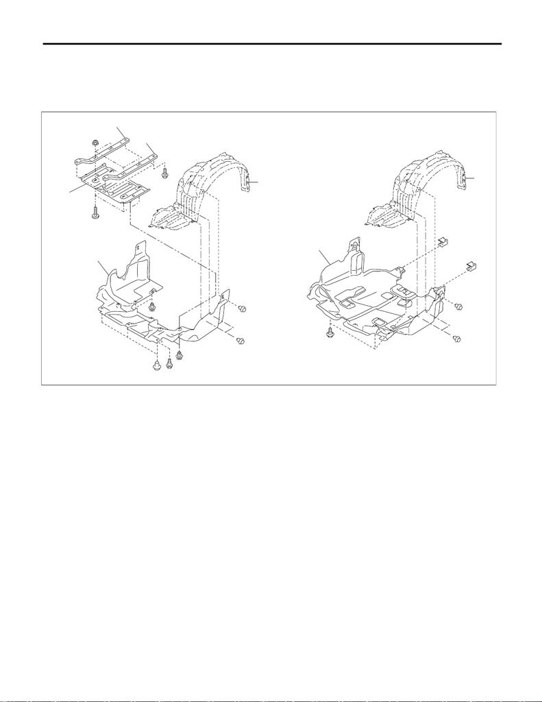

EI-21

Front Under Cover

EXTERIOR/INTERIOR TRIM

2. Front Under Cover

A: REMOVAL

1) Lift up the vehicle.

2) Remove the bolts and clips, and remove the under cover - front.

(1) Under cover - front (except for STI

model)

(3) Plate - CTR RH (except for STI

model)

(5) Mud guard - front

(2) Frame - under cover (except for

STI model)

(4) Plate - CTR LH (except for STI

model)

(6) Under cover - front (STI model)

EI-04347

(6)

(5)

(1)

(3)

(2)

(4)

(5)

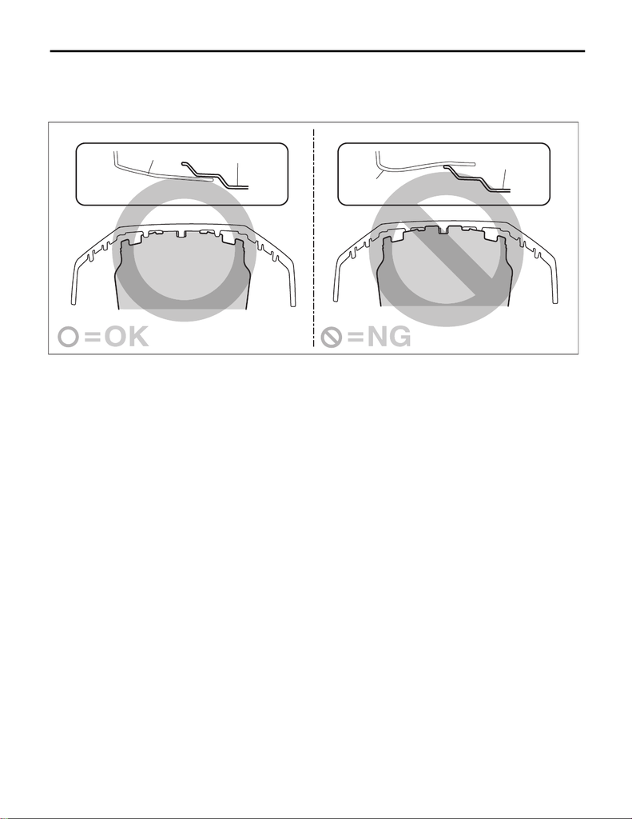

EI-22

Front Under Cover

EXTERIOR/INTERIOR TRIM

B: INSTALLATION

CAUTION:

Install the under cover so that the under cover front end (b) comes inside of the bumper face - front

(a).

1) Install the under cover - front.

Tightening torque:

Refer to “COMPONENT” of “General Description”. <Ref. to EI-3, FRONT UNDER COVER, COMPO-

NENT, General Description.>

2) Lower the vehicle.

EI-04291

(b)

(a)

(b)

(a)